# multidimensional rotating and rank correlations

~

2019-06-12

A fundamental idea in biplot methodology is the *conference of inertia*, a phrase i picked up from [an SO answer by ttnphns](https://stats.stackexchange.com/a/141755/68743) and quickly incorporated into [ordr](https://github.com/corybrunson/ordr/blob/master/R/ord-conference.r). The basic idea arises from the central properties of a biplot, for example in a principal components analysis: Conventionally, a case–variable data matrix $X\in\mathbb{R}^{n\times m}$ of ratio variables[^1] is singular-value decomposed as $X=UDV^\top$ and biplotted with *principal* case coordinates $UD\in\mathbb{R}^{n\times r}$ and *standardized* variable coordinates $V\in\mathbb{R}^{m\times r}$. Under this convention, $U$ and $V$ arise from eigendecompositions of $XX^\top$ and of $X\top X$, respectively, and $D$ is the diagonal matrix of the square roots of their (common) eigenvalues. Because both sets of eigenvectors $U=\left[\,u_1\,\cdots\,u_r\,\right]$ and $V=\left[\,v_1\,\cdots\,v_r\,\right]$ are orthonormal, $U^\top U=I_r=V^\top V$ and the total inertia (variance) in each matrix is $\sum_{j=1}^{r}{{v_j}^2}=r=\sum_{j=1}^{r}{{v_j}^2}$. Instead, $D$ contains all of the inertia of $X$.

```r
x <- scale(mtcars, center = TRUE, scale = TRUE)
sum(x^2)
```

```
## [1] 341
```

```r
x.d <- dist(x)
x.c <- cor(x)
s <- svd(x)
s.d <- dist(s$u %*% diag(s$d))
s.c <- s$v %*% diag(s$d^2) %*% t(s$v)
sum(s$d^2)
```

```
## [1] 341
```

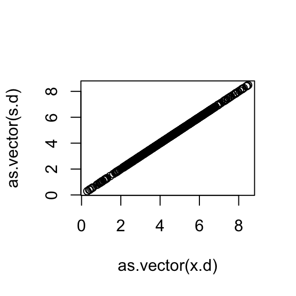

```r
plot(x = as.vector(x.d), y = as.vector(s.d))
```

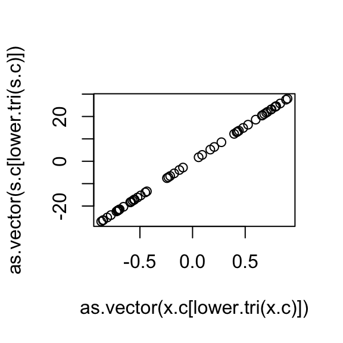

```r
plot(x = as.vector(x.c[lower.tri(x.c)]), y = as.vector(s.c[lower.tri(s.c)]))
```

[^1]: That is to say, if the variables don’t have meaningful zero values and/or commensurate scales, then they should probably be centered to zero mean and/or scaled to unit variance.